# Assignment 4_PCA

2024-03-01

****1. Decide how many Principal Components (PCs) you want to keep and why *****

Starts at Line 92

Reasons for choosing PC1, PC2 and PC3 Standard Deviation [1] PC1, PC2, PC3: Have the majority of standard deviation (Total)

Also cumulative proportion is high for PC1, PC2, PC3 and increasing further indicating ambiguity as it is the proportion of variance explained.

These prinicpal components can be used suitably as per their importance based on proportion. They indicate high correlation with dependent variable and can derive suitable meaning in dataset based on variance too

For analysis refer to all the observations and inferences generated on the study

**Hence choosing PC1, PC2, PC3 for further analysis**

*****Q2. Explain the variate representation each PCs *******

Line 92, reference where analysis starts and ends at visulization

Also check line 682: barplot to show contribution of each variable towards PC1, PC2 and PC3

Observation: (relation crossing 0.30):

[1] PC1: fixed acidity (positive relation),citric acidity (positive relation), pH (negative) indicate highest relativity with PC1 either positive or negative.

[2] PC2: free sulphur dioxide (negative), Total Sulphur dioxide (negative) and alcohol (+ve) relation.

[3] PC3: Volatile acidity (-ve),alcohol has high relation (+ve), free sulphur dioxide (+ve)

Inferences:

****3. Perform some visualization using PCs. (4 points)*** Starts line 557

Observation: [1] Attributes = 12 [2] No. of rows= 1599 [3] independent varaibles datatype = double [4] Dependent varaible datatpye = string

```r
#Library to read csv file
library(readr)
# Read the CSV file
df <- read_csv("C:/Rutgers/Subjects/Spring Sem/Multivariate Analysis/Data/wine.csv")
# converts the DataFrame df to a string representation
str(df)
```

```
## spc_tbl_ [1,599 × 12] (S3: spec_tbl_df/tbl_df/tbl/data.frame)
##  $ fixed acidity       : num [1:1599] 7.4 7.8 7.8 11.2 7.4 7.4 7.9 7.3 7.8 7.5 ...
##  $ volatile acidity    : num [1:1599] 0.7 0.88 0.76 0.28 0.7 0.66 0.6 0.65 0.58 0.5 ...
##  $ citric acid         : num [1:1599] 0 0 0.04 0.56 0 0 0.06 0 0.02 0.36 ...
##  $ residual sugar      : num [1:1599] 1.9 2.6 2.3 1.9 1.9 1.8 1.6 1.2 2 6.1 ...
##  $ chlorides           : num [1:1599] 0.076 0.098 0.092 0.075 0.076 0.075 0.069 0.065 0.073 0.071 ...
##  $ free sulfur dioxide : num [1:1599] 11 25 15 17 11 13 15 15 9 17 ...
##  $ total sulfur dioxide: num [1:1599] 34 67 54 60 34 40 59 21 18 102 ...
##  $ density             : num [1:1599] 0.998 0.997 0.997 0.998 0.998 ...
##  $ pH                  : num [1:1599] 3.51 3.2 3.26 3.16 3.51 3.51 3.3 3.39 3.36 3.35 ...
##  $ sulphates           : num [1:1599] 0.56 0.68 0.65 0.58 0.56 0.56 0.46 0.47 0.57 0.8 ...
##  $ alcohol             : num [1:1599] 9.4 9.8 9.8 9.8 9.4 9.4 9.4 10 9.5 10.5 ...
##  $ quality             : chr [1:1599] "bad" "bad" "bad" "good" ...
##  - attr(*, "spec")=
##   .. cols(
##   ..   `fixed acidity` = col_double(),
##   ..   `volatile acidity` = col_double(),
##   ..   `citric acid` = col_double(),
##   ..   `residual sugar` = col_double(),
##   ..   chlorides = col_double(),
##   ..   `free sulfur dioxide` = col_double(),
##   ..   `total sulfur dioxide` = col_double(),
##   ..   density = col_double(),
##   ..   pH = col_double(),
##   ..   sulphates = col_double(),
##   ..   alcohol = col_double(),
##   ..   quality = col_character()
##   .. )
##  - attr(*, "problems")=<externalptr>
```

```r
#attaching variables of the data frame df
attach(df)
```

```r
#viewing independent variables
df[1:11]
```

```
## # A tibble: 1,599 × 11
##    `fixed acidity` `volatile acidity` `citric acid` `residual sugar` chlorides
##              <dbl>              <dbl>         <dbl>            <dbl>     <dbl>
##  1             7.4               0.7           0                 1.9     0.076
##  2             7.8               0.88          0                 2.6     0.098
##  3             7.8               0.76          0.04              2.3     0.092
##  4            11.2               0.28          0.56              1.9     0.075
##  5             7.4               0.7           0                 1.9     0.076
##  6             7.4               0.66          0                 1.8     0.075
##  7             7.9               0.6           0.06              1.6     0.069
##  8             7.3               0.65          0                 1.2     0.065
##  9             7.8               0.58          0.02              2       0.073
## 10             7.5               0.5           0.36              6.1     0.071
## # ℹ 1,589 more rows
## # ℹ 6 more variables: `free sulfur dioxide` <dbl>,
## #   `total sulfur dioxide` <dbl>, density <dbl>, pH <dbl>, sulphates <dbl>,
## #   alcohol <dbl>
```

Calculating correlation of independent attributes:

Observations: [1] Citric Acid and is positively correlated to fixed acidity = 0.67

[2] pH is negatively correlated to fixed acidity = -0.68

[3] In the following manner noting down all the crucial correlations:

Positive: [a] density and fixed acidity [b] Total Sulphur dioxide and free sulphuric acid=0.66

Negative: [a] Citric acid and Volatile acidity = -0.55 [b] alcohol and density = -0.49

```r
#Get the Correlations between the measurements
cor(df[1:11])
```

```
##                      fixed acidity volatile acidity citric acid residual sugar
## fixed acidity           1.00000000     -0.256130895  0.67170343    0.114776724
## volatile acidity       -0.25613089      1.000000000 -0.55249568    0.001917882
## citric acid             0.67170343     -0.552495685  1.00000000    0.143577162
## residual sugar          0.11477672      0.001917882  0.14357716    1.000000000
## chlorides               0.09370519      0.061297772  0.20382291    0.055609535
## free sulfur dioxide    -0.15379419     -0.010503827 -0.06097813    0.187048995
## total sulfur dioxide   -0.11318144      0.076470005  0.03553302    0.203027882
## density                 0.66804729      0.022026232  0.36494718    0.355283371
## pH                     -0.68297819      0.234937294 -0.54190414   -0.085652422
## sulphates               0.18300566     -0.260986685  0.31277004    0.005527121
## alcohol                -0.06166827     -0.202288027  0.10990325    0.042075437
##                         chlorides free sulfur dioxide total sulfur dioxide
## fixed acidity         0.093705186        -0.153794193          -0.11318144
## volatile acidity      0.061297772        -0.010503827           0.07647000
## citric acid           0.203822914        -0.060978129           0.03553302
## residual sugar        0.055609535         0.187048995           0.20302788
## chlorides             1.000000000         0.005562147           0.04740047
## free sulfur dioxide   0.005562147         1.000000000           0.66766645
## total sulfur dioxide  0.047400468         0.667666450           1.00000000
## density               0.200632327        -0.021945831           0.07126948
## pH                   -0.265026131         0.070377499          -0.06649456
## sulphates             0.371260481         0.051657572           0.04294684
## alcohol              -0.221140545        -0.069408354          -0.20565394
##                          density          pH    sulphates     alcohol
## fixed acidity         0.66804729 -0.68297819  0.183005664 -0.06166827
## volatile acidity      0.02202623  0.23493729 -0.260986685 -0.20228803
## citric acid           0.36494718 -0.54190414  0.312770044  0.10990325
## residual sugar        0.35528337 -0.08565242  0.005527121  0.04207544
## chlorides             0.20063233 -0.26502613  0.371260481 -0.22114054
## free sulfur dioxide  -0.02194583  0.07037750  0.051657572 -0.06940835
## total sulfur dioxide  0.07126948 -0.06649456  0.042946836 -0.20565394
## density               1.00000000 -0.34169933  0.148506412 -0.49617977
## pH                   -0.34169933  1.00000000 -0.196647602  0.20563251
## sulphates             0.14850641 -0.19664760  1.000000000  0.09359475
## alcohol              -0.49617977  0.20563251  0.093594750  1.00000000
```

Goal:

[1] Calculate std deviation of Principal components from the mean indicating some behavior of PC’s based on attributes calculated

example: High values shows high variability in Principle components

Observations:

Standard Deviation [1] PC1, PC2, PC3, PC4, PC5: Have the majority of standard deviation (Total)

[2] PC11, PC10 have the lowest standard deviation indicating less meaning

Rotation (n x k): [Matrix] [1] Indicates relation between original attributes and and Principal Components

Observation: (relation crossing 0.30):

[1] PC1: fixed acidity (positive relation),citric acidity (positive relation), pH (negative) indicate highest relativity with PC1 either positive or negative.

[2] PC2: free sulphur dioxide (negative), Total Sulphur dioxide (negative) and alcohol (+ve) relation.

[3] PC3: Volatile acidity (-ve),alcohol has high relation (+ve), free sulphur dioxide (+ve)

Inferences:

+ve and -ve range in each PC are relation of variables with respective PC’s and their correlation with each other.

PC1, PC2, PC3, PC4 have majority of proportion of variance indicating to be evaluated further.

But cumulative proportion is low for PC1, PC2, PC3 and increasing further indicating ambiguity as it is the proportion of variance explained.

```r
# Using prcomp to compute the principal components (eigenvalues and eigenvectors). With scale=TRUE, variable means are set to zero, and variances set to one

#prcomp: return PCA values of dataframe
#scale: Scaling variables before performing PCA to obtain uniformity in the values
df_pca <- prcomp(df[1:11],scale=TRUE)
df_pca
```

```
## Standard deviations (1, .., p=11):
##  [1] 1.7604353 1.3877715 1.2452082 1.1014684 0.9794346 0.8121627 0.7640623
##  [8] 0.6503512 0.5870623 0.4258323 0.2440457
##
## Rotation (n x k) = (11 x 11):
##                              PC1          PC2         PC3          PC4
## fixed acidity         0.48931422  0.110502738 -0.12330157  0.229617370
## volatile acidity     -0.23858436 -0.274930480 -0.44996253 -0.078959783
## citric acid           0.46363166  0.151791356  0.23824707  0.079418256
## residual sugar        0.14610715 -0.272080238  0.10128338  0.372792562
## chlorides             0.21224658 -0.148051555 -0.09261383 -0.666194756
## free sulfur dioxide  -0.03615752 -0.513566812  0.42879287  0.043537818
## total sulfur dioxide  0.02357485 -0.569486959  0.32241450  0.034577115
## density               0.39535301 -0.233575490 -0.33887135  0.174499758
## pH                   -0.43851962 -0.006710793  0.05769735  0.003787746
## sulphates             0.24292133  0.037553916  0.27978615 -0.550872362
## alcohol              -0.11323206  0.386180959  0.47167322  0.122181088
##                              PC5         PC6         PC7         PC8
## fixed acidity        -0.08261366 -0.10147858  0.35022736 -0.17759545
## volatile acidity      0.21873452 -0.41144893  0.53373510 -0.07877531
## citric acid          -0.05857268 -0.06959338 -0.10549701 -0.37751558
## residual sugar        0.73214429 -0.04915555 -0.29066341  0.29984469
## chlorides             0.24650090 -0.30433857 -0.37041337 -0.35700936
## free sulfur dioxide  -0.15915198  0.01400021  0.11659611 -0.20478050
## total sulfur dioxide -0.22246456 -0.13630755  0.09366237  0.01903597
## density               0.15707671  0.39115230  0.17048116 -0.23922267
## pH                    0.26752977  0.52211645  0.02513762 -0.56139075
## sulphates             0.22596222  0.38126343  0.44746911  0.37460432
## alcohol               0.35068141 -0.36164504  0.32765090 -0.21762556
##                               PC9        PC10         PC11
## fixed acidity        -0.194020908  0.24952314 -0.639691452
## volatile acidity      0.129110301 -0.36592473 -0.002388597
## citric acid           0.381449669 -0.62167708  0.070910304
## residual sugar       -0.007522949 -0.09287208 -0.184029964
## chlorides            -0.111338666  0.21767112 -0.053065322
## free sulfur dioxide  -0.635405218 -0.24848326  0.051420865
## total sulfur dioxide  0.592115893  0.37075027 -0.068701598
## density              -0.020718675  0.23999012  0.567331898
## pH                    0.167745886  0.01096960 -0.340710903
## sulphates             0.058367062 -0.11232046 -0.069555381
## alcohol              -0.037603106  0.30301450  0.314525906
```

```r
summary(df_pca)
```

```
## Importance of components:
##                           PC1    PC2    PC3    PC4     PC5     PC6     PC7
## Standard deviation     1.7604 1.3878 1.2452 1.1015 0.97943 0.81216 0.76406
## Proportion of Variance 0.2817 0.1751 0.1410 0.1103 0.08721 0.05996 0.05307
## Cumulative Proportion  0.2817 0.4568 0.5978 0.7081 0.79528 0.85525 0.90832
##                            PC8     PC9    PC10    PC11
## Standard deviation     0.65035 0.58706 0.42583 0.24405
## Proportion of Variance 0.03845 0.03133 0.01648 0.00541
## Cumulative Proportion  0.94677 0.97810 0.99459 1.00000
```

Checking attributes in PCA performed

```r
#attributes(df_pca) below mentioned can be viewed by this function
attributes(df_pca)
```

```
## $names
## [1] "sdev"     "rotation" "center"   "scale"    "x"
##
## $class
## [1] "prcomp"
```

Checking sample scores of PC’s in x

```r
# sample scores stored in df_pca$x
df_pca$x
```

[output not shown]

[output cut: 4785 more lines]

Checking eigen vectors:

To check composition of each attribute in respective PC’s

[1]

```r
# loading (eigenvectors) are stored in df_pca$rotation
df_pca$rotation
```

```
##                              PC1          PC2         PC3          PC4
## fixed acidity         0.48931422  0.110502738 -0.12330157  0.229617370
## volatile acidity     -0.23858436 -0.274930480 -0.44996253 -0.078959783
## citric acid           0.46363166  0.151791356  0.23824707  0.079418256
## residual sugar        0.14610715 -0.272080238  0.10128338  0.372792562
## chlorides             0.21224658 -0.148051555 -0.09261383 -0.666194756
## free sulfur dioxide  -0.03615752 -0.513566812  0.42879287  0.043537818
## total sulfur dioxide  0.02357485 -0.569486959  0.32241450  0.034577115
## density               0.39535301 -0.233575490 -0.33887135  0.174499758
## pH                   -0.43851962 -0.006710793  0.05769735  0.003787746
## sulphates             0.24292133  0.037553916  0.27978615 -0.550872362
## alcohol              -0.11323206  0.386180959  0.47167322  0.122181088
##                              PC5         PC6         PC7         PC8
## fixed acidity        -0.08261366 -0.10147858  0.35022736 -0.17759545
## volatile acidity      0.21873452 -0.41144893  0.53373510 -0.07877531
## citric acid          -0.05857268 -0.06959338 -0.10549701 -0.37751558
## residual sugar        0.73214429 -0.04915555 -0.29066341  0.29984469
## chlorides             0.24650090 -0.30433857 -0.37041337 -0.35700936
## free sulfur dioxide  -0.15915198  0.01400021  0.11659611 -0.20478050
## total sulfur dioxide -0.22246456 -0.13630755  0.09366237  0.01903597
## density               0.15707671  0.39115230  0.17048116 -0.23922267
## pH                    0.26752977  0.52211645  0.02513762 -0.56139075
## sulphates             0.22596222  0.38126343  0.44746911  0.37460432
## alcohol               0.35068141 -0.36164504  0.32765090 -0.21762556
##                               PC9        PC10         PC11
## fixed acidity        -0.194020908  0.24952314 -0.639691452
## volatile acidity      0.129110301 -0.36592473 -0.002388597
## citric acid           0.381449669 -0.62167708  0.070910304
## residual sugar       -0.007522949 -0.09287208 -0.184029964
## chlorides            -0.111338666  0.21767112 -0.053065322
## free sulfur dioxide  -0.635405218 -0.24848326  0.051420865
## total sulfur dioxide  0.592115893  0.37075027 -0.068701598
## density              -0.020718675  0.23999012  0.567331898
## pH                    0.167745886  0.01096960 -0.340710903
## sulphates             0.058367062 -0.11232046 -0.069555381
## alcohol              -0.037603106  0.30301450  0.314525906
```

```r
# variable means stored in df_pca$center
df_pca$center
```

```
##        fixed acidity     volatile acidity          citric acid
##           8.31963727           0.52782051           0.27097561
##       residual sugar            chlorides  free sulfur dioxide
##           2.53880550           0.08746654          15.87492183
## total sulfur dioxide              density                   pH
##          46.46779237           0.99674668           3.31111320
##            sulphates              alcohol
##           0.65814884          10.42298311
```

```r
# variable standard deviations stored in df_pca$scale
df_pca$scale
```

```
##        fixed acidity     volatile acidity          citric acid
##          1.741096318          0.179059704          0.194801137
##       residual sugar            chlorides  free sulfur dioxide
##          1.409928060          0.047065302         10.460156970
## total sulfur dioxide              density                   pH
##         32.895324478          0.001887334          0.154386465
##            sulphates              alcohol
##          0.169506980          1.065667582
```

Observation:

Eigen values are the center data points in the vector which do not change a lot after rotation.

Calculating Eigen vector values/Standard Deviation information contained by each PC’s Function: df_pca$sdev^2

Squaring to penalize and show the impact of each std deviation

[1] PC1: contains the highest standard deviation: 3.09913244

[2] PC2, PC3, PC4, PC5: 1.92590969 1.55054349 1.21323253 0.95929207 Following principal components contain high amount of standard deviation information.

```r
# singular values (square roots of eigenvalues) stored in df$sdev
# A table containing eigenvalues and %'s accounted, follows
# Eigenvalues are sdev^2

(eigen_df <- df_pca$sdev^2)
```

```
##  [1] 3.09913244 1.92590969 1.55054349 1.21323253 0.95929207 0.65960826
##  [7] 0.58379122 0.42295670 0.34464212 0.18133317 0.05955831
```

```r
names(eigen_df) <- paste("PC",1:11,sep="") #formatting PC with column no. for respective PC's
eigen_df
```

```
##        PC1        PC2        PC3        PC4        PC5        PC6        PC7
## 3.09913244 1.92590969 1.55054349 1.21323253 0.95929207 0.65960826 0.58379122
##        PC8        PC9       PC10       PC11
## 0.42295670 0.34464212 0.18133317 0.05955831
```

Summation of eigen_df calculated with standard deviation and eigen values always amount to the number of Principal components present

```r
sumlambdas <- sum(eigen_df)
sumlambdas
```

```
## [1] 11
```

Scaling/Proportioning the Principal component eigen values by diving by the sum values of eigen values calculated for each PC’s

Even with scaling we can observe that

[1] PC1, PC2, PC3, PC4, PC5 hold the majority percentage of eigen values

starting in order from: 28%, 17%, 14%, 11%, 8%

[2] Rest of the PC’s do not hold high proportion of std deviation indicating less meaning.

```r
propvar <- eigen_df/sumlambdas
propvar
```

```
##         PC1         PC2         PC3         PC4         PC5         PC6
## 0.281739313 0.175082699 0.140958499 0.110293866 0.087208370 0.059964388
##         PC7         PC8         PC9        PC10        PC11
## 0.053071929 0.038450609 0.031331102 0.016484833 0.005414392
```

cumsum(propvar): is used to add the values (Indicating increase in cumulative proportion) of previous Principal components to the next Principal component totalling to 1 as the values are scaled from 0 to 1

Barplot to explain cumulative contribution of each PC’s

Obervation:

```r
library(waterfall)
cumvar_df <- cumsum(propvar)
cumvar_df
```

```
##       PC1       PC2       PC3       PC4       PC5       PC6       PC7       PC8
## 0.2817393 0.4568220 0.5977805 0.7080744 0.7952827 0.8552471 0.9083191 0.9467697
##       PC9      PC10      PC11
## 0.9781008 0.9945856 1.0000000
```

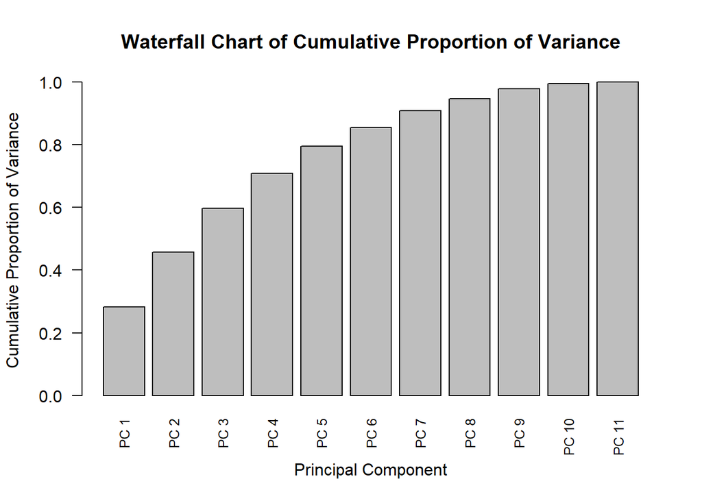

```r
# Load the waterfall package
library(waterfall)

# Create a data frame for the waterfall chart
waterfall_data <- data.frame(
  labels = paste("PC", 1:length(propvar)),
  values = propvar
)

# Calculate the cumulative sum of the proportion of variance
cumulative_propvar <- cumsum(waterfall_data$values)

# Plot the waterfall chart with rotated x-axis labels
barplot(cumulative_propvar, names.arg = waterfall_data$labels,
        main = "Waterfall Chart of Cumulative Proportion of Variance",
        xlab = "Principal Component", ylab = "Cumulative Proportion of Variance",
        las = 2, cex.names = 0.8)  # las = 2 for vertical labels, cex.names to adjust label size
```

```r
#Based on the cumulative plot we can select PC1 to PC5 as they indicate high contribution to the total
```

eigen_df: This seems to be a data frame containing information about eigenvectors or eigenvalues from some analysis.

propvar: This is likely a vector containing the proportion of variance explained by each principal component.

cumvar_df: This could be another data frame containing cumulative proportion of variance explained by each principal component.

rbind(eigen_df,propvar,cumvar_df): to combine above mentioned dataframes

Observation:

matlambdas: (Combined dataframe) [1] PC1 and PC2 have highest proportion of eigen values indicating highest variance captured

[2] Hence proportion of variance is highest for PC1 and PC2

Second Observation is for original PCA vector: (same as above just not combined hence showing lesser values)

[1] PC1 and PC2 have highest proportion of eigen values indicating highest variance captured

[2] Hence proportion of variance is highest for PC1 and PC2

```r
#Combining mulltiple dataframes of PCA calculation done
matlambdas <- rbind(eigen_df,propvar,cumvar_df)

#Assigning row names to combined data frame
rownames(matlambdas) <- c("Eigenvalues","Prop. variance","Cum. prop. variance")

#rounding values of combined dataframe to 4 decimal points
round(matlambdas,4)
```

```
##                        PC1    PC2    PC3    PC4    PC5    PC6    PC7    PC8
## Eigenvalues         3.0991 1.9259 1.5505 1.2132 0.9593 0.6596 0.5838 0.4230
## Prop. variance      0.2817 0.1751 0.1410 0.1103 0.0872 0.0600 0.0531 0.0385
## Cum. prop. variance 0.2817 0.4568 0.5978 0.7081 0.7953 0.8552 0.9083 0.9468
##                        PC9   PC10   PC11
## Eigenvalues         0.3446 0.1813 0.0596
## Prop. variance      0.0313 0.0165 0.0054
## Cum. prop. variance 0.9781 0.9946 1.0000
```

```r
summary(matlambdas)
```

```
##       PC1              PC2              PC3              PC4
##  Min.   :0.2817   Min.   :0.1751   Min.   :0.1410   Min.   :0.1103
##  1st Qu.:0.2817   1st Qu.:0.3160   1st Qu.:0.3694   1st Qu.:0.4092
##  Median :0.2817   Median :0.4568   Median :0.5978   Median :0.7081
##  Mean   :1.2209   Mean   :0.8526   Mean   :0.7631   Mean   :0.6772
##  3rd Qu.:1.6904   3rd Qu.:1.1914   3rd Qu.:1.0742   3rd Qu.:0.9607
##  Max.   :3.0991   Max.   :1.9259   Max.   :1.5505   Max.   :1.2132
##       PC5               PC6               PC7               PC8
##  Min.   :0.08721   Min.   :0.05996   Min.   :0.05307   Min.   :0.03845
##  1st Qu.:0.44125   1st Qu.:0.35979   1st Qu.:0.31843   1st Qu.:0.23070
##  Median :0.79528   Median :0.65961   Median :0.58379   Median :0.42296
##  Mean   :0.61393   Mean   :0.52494   Mean   :0.51506   Mean   :0.46939
##  3rd Qu.:0.87729   3rd Qu.:0.75743   3rd Qu.:0.74606   3rd Qu.:0.68486
##  Max.   :0.95929   Max.   :0.85525   Max.   :0.90832   Max.   :0.94677
##       PC9               PC10              PC11
##  Min.   :0.03133   Min.   :0.01648   Min.   :0.005414
##  1st Qu.:0.18799   1st Qu.:0.09891   1st Qu.:0.032486
##  Median :0.34464   Median :0.18133   Median :0.059558
##  Mean   :0.45136   Mean   :0.39747   Mean   :0.354991
##  3rd Qu.:0.66137   3rd Qu.:0.58796   3rd Qu.:0.529779
##  Max.   :0.97810   Max.   :0.99459   Max.   :1.000000
```

```r
summary(df_pca)
```

```
## Importance of components:
##                           PC1    PC2    PC3    PC4     PC5     PC6     PC7
## Standard deviation     1.7604 1.3878 1.2452 1.1015 0.97943 0.81216 0.76406
## Proportion of Variance 0.2817 0.1751 0.1410 0.1103 0.08721 0.05996 0.05307
## Cumulative Proportion  0.2817 0.4568 0.5978 0.7081 0.79528 0.85525 0.90832
##                            PC8     PC9    PC10    PC11
## Standard deviation     0.65035 0.58706 0.42583 0.24405
## Proportion of Variance 0.03845 0.03133 0.01648 0.00541
## Cumulative Proportion  0.94677 0.97810 0.99459 1.00000
```

Mapping Dependent variable with PC1 and PC2:

Observations:

[1] Quality=Bad are both negative and positive components of PC1 and PC2 but more towards negative

[2] Quality = Good are capturing both negative and positive value in most of the Principal Components but more towards positive

```r
# Identifying the scores by their Quality of wine
dftyp_pca <- cbind(data.frame(quality),df_pca$x)
dftyp_pca
```

[output not shown]

[output cut: 4785 more lines]

Now after aggregating:

Obervations:

PC3: had correlation with variations Alcohol

refer to correlations mapped earlier to decode PCA and analyse to get meaning from variables.

[2] PC2: free sulphur dioxide (negative), Total Sulphur dioxide (negative) and alcohol (+ve) relation.

[3] PC3: Volatile acidity (-ve),alcohol has high relation (+ve), free sulphur dioxide (+ve)

```r
# Means of scores for all the PC's classified by Quality status
tabmeansPC <- aggregate(dftyp_pca[,2:6],by=list(quality=df$quality),mean)
tabmeansPC
```

```
##   quality        PC1        PC2        PC3         PC4        PC5
## 1     bad -0.1205425 -0.5539665 -0.4278955 -0.02839395 -0.1299321
## 2    good  0.1048931  0.4820480  0.3723441  0.02470772  0.1130637
```

sorted indices to rearrange the rows of the data frame tabmeansPC, resulting in a new data frame where the rows are sorted based on the values in the “quality” column in descending order.

```r
tabmeansPC <- tabmeansPC[rev(order(tabmeansPC$quality)),]
tabmeansPC
```

```
##   quality        PC1        PC2        PC3         PC4        PC5
## 2    good  0.1048931  0.4820480  0.3723441  0.02470772  0.1130637
## 1     bad -0.1205425 -0.5539665 -0.4278955 -0.02839395 -0.1299321
```

2- indicates quality = good 1- indicates quality = bad

[1] Good quality wine is displaying +ve correlation

[3] also PC2 and PC3 have highest varibility with PC2 and PC3 indicating high variability for good and bad wine indicating a good criteria to differentiate and understand relation of variables with dependent variable

```r
tabfmeans <- t(tabmeansPC[,-1])
tabfmeans
```

```
##              2           1
## PC1 0.10489313 -0.12054251
## PC2 0.48204803 -0.55396649
## PC3 0.37234415 -0.42789549
## PC4 0.02470772 -0.02839395
## PC5 0.11306368 -0.12993206
```

Mapped values:

[1] Good quality wine is displaying +ve correlation

[3] also PC2 and PC3 have highest varibility with PC2 and PC3 indicating high variability for good and bad wine indicating a good criteria to differentiate and understand relation of variables with dependent variable

```r
colnames(tabfmeans) <- t(as.vector(tabmeansPC[1]$quality))
tabfmeans
```

```
##           good         bad
## PC1 0.10489313 -0.12054251
## PC2 0.48204803 -0.55396649
## PC3 0.37234415 -0.42789549
## PC4 0.02470772 -0.02839395
## PC5 0.11306368 -0.12993206
```

dftyp_pca[,2:11]: This part selects columns 2 to 11 (inclusive) from the data frame

dftyp_pca. It subsets the data frame to include only these specific columns.

by: This argument specifies the grouping variable or variables. In this case, it’s specified as list(quality = df$quality), which means that the data will be grouped by the values of the “quality” column from the data frame df.

sd (Standard deviation): This is the function that will be applied to each subset of the data. In this case, it’s sd, which calculates the standard deviation.

after calculating standard deviation, transposition is done

viewing std deviation of Dependent variable with respect to PC’s.

Observation:

```r
# Standard deviations of scores for all the PC's classified by Quality status
tabsdsPC <- aggregate(dftyp_pca[,2:11],by=list(quality=df$quality),sd)

#Transpose the resulting subset by transposition on rows and columns of PC's and Quality
tabfsds <- t(tabsdsPC[,-1])

colnames(tabfsds) <- t(as.vector(tabsdsPC[1]$quality))
tabfsds
```

```
##            bad      good
## PC1  1.6712482 1.8290347
## PC2  1.3320046 1.2490520
## PC3  1.0934233 1.2501508
## PC4  1.2697679 0.9306623
## PC5  1.0013641 0.9461063
## PC6  0.8055277 0.8167378
## PC7  0.7659343 0.7568395
## PC8  0.6728227 0.6298228
## PC9  0.6231237 0.5415072
## PC10 0.4422690 0.4105856
```

t-test of PC1 to PC5 with dependent varaible to obtain mean based on t-value and p-value

T-test: t-test of PC1 to PC5 with dependent varaible to obtain mean based on t-value and p-value:

Inference (PC1): The variability in PC1 scores differs significantly between the “bad” and “good” quality groups, indicating that PC1 may capture important differences related to wine quality.

[2] PC2: The ratio of variances between the two quality groups is not significantly different from 1 (p-value = 0.06941).

[3] PC3: The ratio of variances between the two quality groups is significantly different from 1 (p-value = 0.0001727).

Inference (PC3): PC3 also exhibits significant differences in variability between the two quality groups, suggesting that PC3 may be informative for distinguishing between “bad” and “good” quality wines.

[4] PC4: The ratio of variances between the two quality groups is significantly different from 1 (p-value < 0.00000000000000022).

Inference (PC4):

PC4 shows substantial variability differences, further indicating its potential relevance for discriminating between wine qualities.

[5] PC5: The ratio of variances between the two quality groups is not significantly different from 1 (p-value = 0.1089).

```r
t.test(PC1~df$quality,data=dftyp_pca)
```

```
##
##  Welch Two Sample t-test
##
## data:  PC1 by df$quality
## t = -2.5746, df = 1593.2, p-value = 0.01012
## alternative hypothesis: true difference in means between group bad and group good is not equal to 0
## 95 percent confidence interval:
##  -0.39718151 -0.05368977
## sample estimates:
##  mean in group bad mean in group good
##         -0.1205425          0.1048931
```

```r
t.test(PC2~df$quality,data=dftyp_pca)
```

```
##
##  Welch Two Sample t-test
##
## data:  PC2 by df$quality
## t = -15.968, df = 1533.8, p-value < 2.2e-16
## alternative hypothesis: true difference in means between group bad and group good is not equal to 0
## 95 percent confidence interval:
##  -1.1632778 -0.9087512
## sample estimates:
##  mean in group bad mean in group good
##         -0.5539665          0.4820480
```

```r
t.test(PC3~df$quality,data=dftyp_pca)
```

```
##
##  Welch Two Sample t-test
##
## data:  PC3 by df$quality
## t = -13.654, df = 1597, p-value < 2.2e-16
## alternative hypothesis: true difference in means between group bad and group good is not equal to 0
## 95 percent confidence interval:
##  -0.9151961 -0.6852832
## sample estimates:
##  mean in group bad mean in group good
##         -0.4278955          0.3723441
```

```r
t.test(PC4~df$quality,data=dftyp_pca)
```

```
##
##  Welch Two Sample t-test
##
## data:  PC4 by df$quality
## t = -0.94165, df = 1344.4, p-value = 0.3465
## alternative hypothesis: true difference in means between group bad and group good is not equal to 0
## 95 percent confidence interval:
##  -0.16372836  0.05752503
## sample estimates:
##  mean in group bad mean in group good
##        -0.02839395         0.02470772
```

```r
t.test(PC5~df$quality,data=dftyp_pca)
```

```
##
##  Welch Two Sample t-test
##
## data:  PC5 by df$quality
## t = -4.9656, df = 1538.1, p-value = 7.61e-07
## alternative hypothesis: true difference in means between group bad and group good is not equal to 0
## 95 percent confidence interval:
##  -0.3389829 -0.1470085
## sample estimates:
##  mean in group bad mean in group good
##         -0.1299321          0.1130637
```

Performing F-test to calculate Variance for Principle components w.r.t Dependent variable:

Observations:

PC1: The F-test result shows a p-value of 0.01129, indicating a significant difference in variances between the “bad” and “good” quality groups for PC1.

Conclusion:

In summary, PC1, PC3, and PC4 exhibit significant differences in variances between the “bad” and “good” quality groups, while PC2 and PC5 do not show significant differences. These results provide insights into the variability of principal component scores across different wine quality groups.

```r
options(scipen=999)
## F ratio tests
var.test(PC1~df$quality,data=dftyp_pca)
```

```
##
##  F test to compare two variances
##
## data:  PC1 by df$quality
## F = 0.83491, num df = 743, denom df = 854, p-value = 0.01129
## alternative hypothesis: true ratio of variances is not equal to 1
## 95 percent confidence interval:
##  0.7266931 0.9598895
## sample estimates:
## ratio of variances
##          0.8349068
```

```r
var.test(PC2~df$quality,data=dftyp_pca)
```

```
##
##  F test to compare two variances
##
## data:  PC2 by df$quality
## F = 1.1372, num df = 743, denom df = 854, p-value = 0.06941
## alternative hypothesis: true ratio of variances is not equal to 1
## 95 percent confidence interval:
##  0.9898364 1.3074757
## sample estimates:
## ratio of variances
##           1.137236
```

```r
var.test(PC3~df$quality,data=dftyp_pca)
```

```
##
##  F test to compare two variances
##
## data:  PC3 by df$quality
## F = 0.76498, num df = 743, denom df = 854, p-value = 0.0001727
## alternative hypothesis: true ratio of variances is not equal to 1
## 95 percent confidence interval:
##  0.6658324 0.8794985
## sample estimates:
## ratio of variances
##          0.7649832
```

```r
var.test(PC4~df$quality,data=dftyp_pca)
```

```
##
##  F test to compare two variances
##
## data:  PC4 by df$quality
## F = 1.8615, num df = 743, denom df = 854, p-value < 0.00000000000000022
## alternative hypothesis: true ratio of variances is not equal to 1
## 95 percent confidence interval:
##  1.620233 2.140167
## sample estimates:
## ratio of variances
##           1.861506
```

```r
var.test(PC5~df$quality,data=dftyp_pca)
```

```
##
##  F test to compare two variances
##
## data:  PC5 by df$quality
## F = 1.1202, num df = 743, denom df = 854, p-value = 0.1089
## alternative hypothesis: true ratio of variances is not equal to 1
## 95 percent confidence interval:
##  0.9750283 1.2879156
## sample estimates:
## ratio of variances
##           1.120222
```

Goal: Levene’s tests (one-sided): The one-sided p-value indicates the probability of observing a result as extreme as the one observed, assuming that the variances of the two groups are different in the direction of interest.

In summary, this code segment is useful for assessing whether there are significant differences in variances between the “bad” and “good” quality groups for each principal component, providing insights into the homogeneity of variances across different quality groups.

Observations and Inferences: Chosen PC’s: PC1, PC2, PC3, PC4, PC5

PC1:

The F value is 9.7234 with a corresponding p-value of 0.001852. The p-value is significant at the 0.01 level. Inference: There is evidence to suggest that the variances of PC1 scores between the two groups (“bad” and “good” quality) are significantly different.

PC2:

The F value is 3.0446 with a corresponding p-value of 0.0812. The p-value is not significant at the 0.05 level. Inference: There is no strong evidence to suggest that the variances of PC2 scores between the two groups are significantly different.

PC3:

The F value is 8.864 with a corresponding p-value of 0.002952. The p-value is significant at the 0.01 level. Inference: There is evidence to suggest that the variances of PC3 scores between the two groups are significantly different.

PC4:

The F value is 4.6593 with a corresponding p-value of 0.03103. The p-value is significant at the 0.05 level. Inference: There is evidence to suggest that the variances of PC4 scores between the two groups are significantly different.

PC5:

The F value is 2.518 with a corresponding p-value of 0.1128. The p-value is not significant at the 0.05 level. Inference: There is no strong evidence to suggest that the variances of PC5 scores between the two groups are significantly different.

```r
# Levene's tests (one-sided)
library(car)
#leveneTest function takes the formula PC(1 to 5)~df$quality where PC1 represents the scores of PC1 to 5 and df$quality represents the quality groups.

#eg: (p_PC1_1sided <- LTPC1[[3]][1]/2 : extracts the p-value from the result of the Levene's test for PC1 and divides it by 2 to get a one-sided p-value.

(LTPC1 <- leveneTest(PC1~df$quality,data=dftyp_pca))
```

```
## Levene's Test for Homogeneity of Variance (center = median)
##         Df F value   Pr(>F)
## group    1  9.7234 0.001852 **
##       1597
## ---
## Signif. codes:  0 '***' 0.001 '**' 0.01 '*' 0.05 '.' 0.1 ' ' 1
```

```r
(p_PC1_1sided <- LTPC1[[3]][1]/2)
```

```
## [1] 0.0009259385
```

```r
(LTPC2 <- leveneTest(PC2~df$quality,data=dftyp_pca))
```

```
## Levene's Test for Homogeneity of Variance (center = median)
##         Df F value Pr(>F)
## group    1  3.0446 0.0812 .
##       1597
## ---
## Signif. codes:  0 '***' 0.001 '**' 0.01 '*' 0.05 '.' 0.1 ' ' 1
```

```r
(p_PC2_1sided=LTPC2[[3]][1]/2)
```

```
## [1] 0.04059939
```

```r
(LTPC3 <- leveneTest(PC3~df$quality,data=dftyp_pca))
```

```
## Levene's Test for Homogeneity of Variance (center = median)
##         Df F value   Pr(>F)
## group    1   8.864 0.002952 **
##       1597
## ---
## Signif. codes:  0 '***' 0.001 '**' 0.01 '*' 0.05 '.' 0.1 ' ' 1
```

```r
(p_PC3_1sided <- LTPC3[[3]][1]/2)
```

```
## [1] 0.001476128
```

```r
(LTPC4 <- leveneTest(PC4~df$quality,data=dftyp_pca))
```

```
## Levene's Test for Homogeneity of Variance (center = median)
##         Df F value  Pr(>F)
## group    1  4.6593 0.03103 *
##       1597
## ---
## Signif. codes:  0 '***' 0.001 '**' 0.01 '*' 0.05 '.' 0.1 ' ' 1
```

```r
(p_PC4_1sided <- LTPC4[[3]][1]/2)
```

```
## [1] 0.015517
```

```r
(LTPC5 <- leveneTest(PC5~df$quality,data=dftyp_pca))
```

```
## Levene's Test for Homogeneity of Variance (center = median)
##         Df F value Pr(>F)
## group    1   2.518 0.1128
##       1597
```

```r
(p_PC5_1sided <- LTPC5[[3]][1]/2)
```

```
## [1] 0.05637501
```

Observations:

Quality= good

PC2 and PC3: seems to be correlated to Good quality wine, as green data points are densely populated towards positive value of PC2 and PC3 x-axis, y-axis

Quality = bad

seems to be uniformly distributed but skewed little towards negative scale of x-axis(PC2).

****Visualization ****

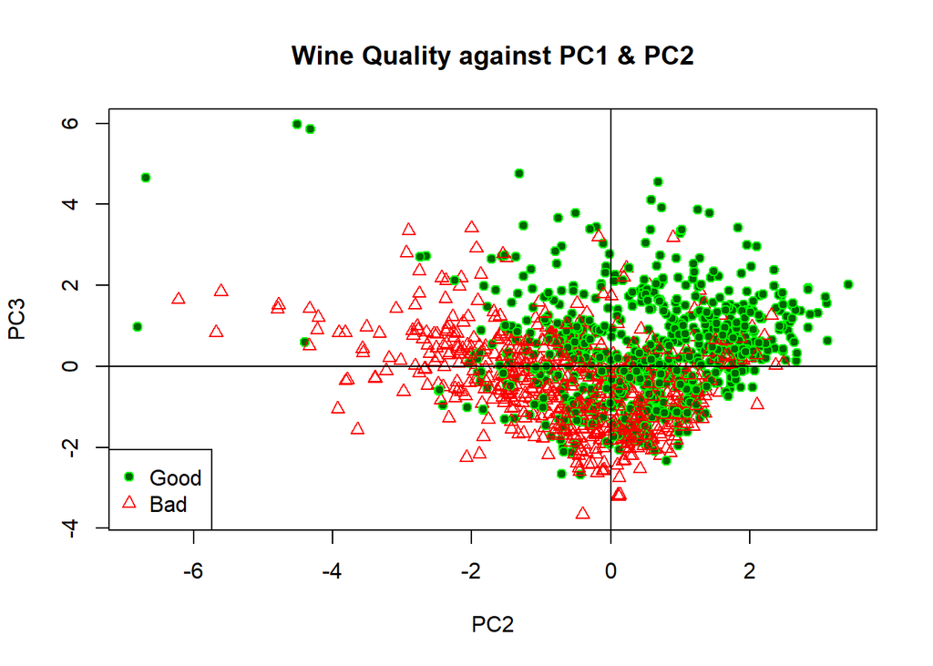

```r
# Plotting the scores for the first and second components
plot(dftyp_pca$PC2, dftyp_pca$PC3,
     pch = ifelse(dftyp_pca$quality == "good", 21, 2),  # Circles with a border for "Good", triangles for "Bad"
     bg = ifelse(dftyp_pca$quality == "good", "#006400", "red"),  # Darker green for "Good" points
     col = ifelse(dftyp_pca$quality == "good", "green", "red"),  # Color assignment for the border
     cex = 1,  # Normal size for both "Good" and "Bad"
     xlab = "PC2", ylab = "PC3", main = "Wine Quality against PC1 & PC2")
abline(h = 0)
abline(v = 0)
legend("bottomleft", legend = c("Good", "Bad"), pch = c(21, 2), col = c("green", "red"), pt.bg = c("#006400", NA))
```

Observations: log(eigen value)

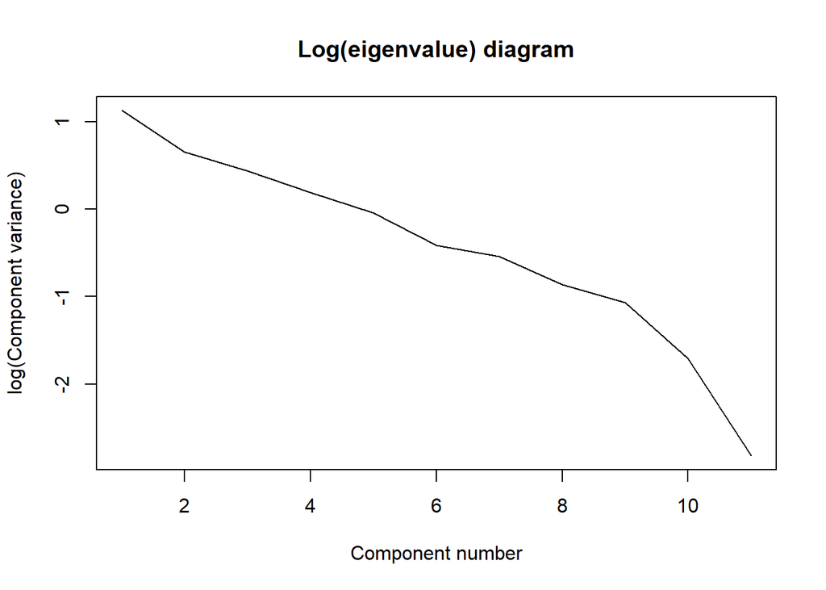

```r
plot(log(eigen_df), xlab = "Component number",ylab = "log(Component variance)", type="l",main = "Log(eigenvalue) diagram")
```

```r
print(summary(df_pca))
```

```
## Importance of components:
##                           PC1    PC2    PC3    PC4     PC5     PC6     PC7
## Standard deviation     1.7604 1.3878 1.2452 1.1015 0.97943 0.81216 0.76406
## Proportion of Variance 0.2817 0.1751 0.1410 0.1103 0.08721 0.05996 0.05307
## Cumulative Proportion  0.2817 0.4568 0.5978 0.7081 0.79528 0.85525 0.90832
##                            PC8     PC9    PC10    PC11
## Standard deviation     0.65035 0.58706 0.42583 0.24405
## Proportion of Variance 0.03845 0.03133 0.01648 0.00541
## Cumulative Proportion  0.94677 0.97810 0.99459 1.00000
```

setting up axis for next plot

steps:

[1] covariance of x attribute of pca data frame and apply diagonal

[2] then calculate range for upper and lower bound of x axis

```r
diag(cov(df_pca$x))
```

```
##        PC1        PC2        PC3        PC4        PC5        PC6        PC7
## 3.09913244 1.92590969 1.55054349 1.21323253 0.95929207 0.65960826 0.58379122
##        PC8        PC9       PC10       PC11
## 0.42295670 0.34464212 0.18133317 0.05955831
```

```r
xlim <- range(df_pca$x[,1])
df_pca$x[,1]
```

[output not shown]

[output cut: 305 more lines]

```r
df_pca$x
```

[output not shown]

[output cut: 4785 more lines]

Observations:

[1] PC1 to PC4 seem to have variance above one indicating meaning and should be visualized and decoded further

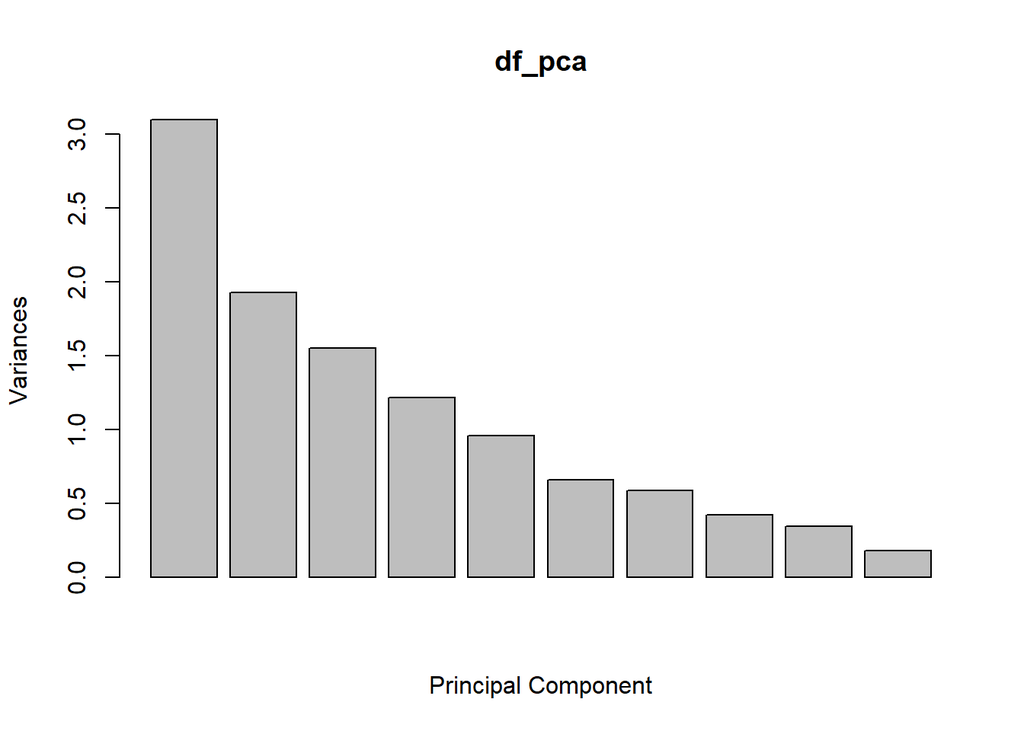

```r
plot(df_pca, xlab = "Principal Component")
```

```r
#get the original value of the data based on PCA
center <- df_pca$center #loading center values of PCA during transformation

scale <- df_pca$scale  # retrieves the scaling values used during the PCA transformation.


new_df <- as.matrix(df[1:11])
new_df
```

[output not shown]

[output cut: 4785 more lines]

scale(new_df,center=center, scale=scale):

scales the original data new_df using the centering and scaling values obtained during PCA.

%*%df_pca$rotation[,1]:

performs matrix multiplication of the scaled data with the first principal component obtained from PCA, which essentially projects the data onto the first principal component.

From this we can further extract information and contribution of each attribute in respective principal components.

```r
drop(scale(new_df,center=center, scale=scale)%*%df_pca$rotation[,1])
```

[output not shown]

[output cut: 305 more lines]

```r
predict(df_pca)[,1]
```

[output not shown]

[output cut: 305 more lines]

Univariate plot to understand :

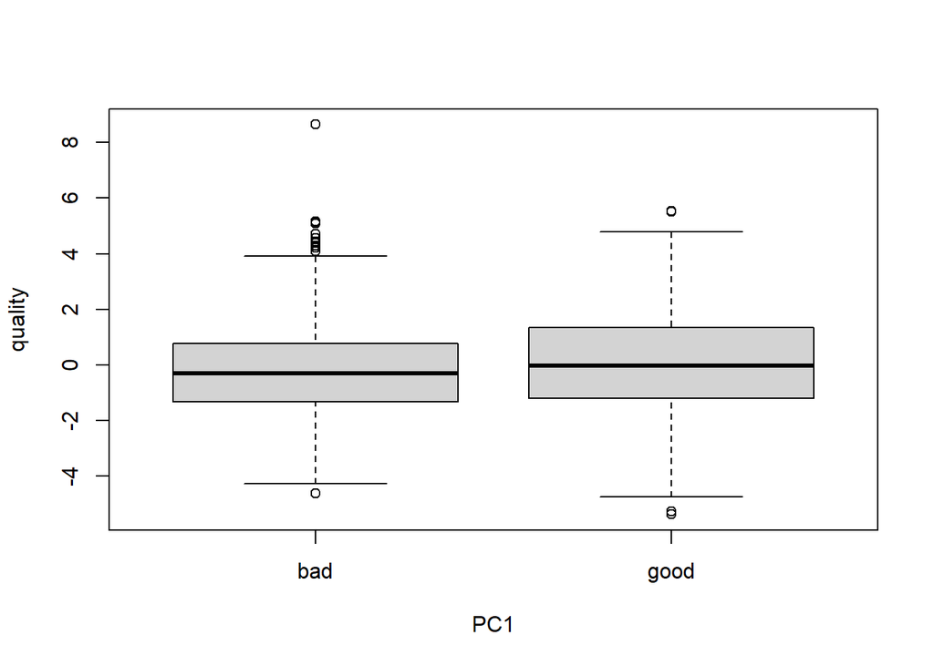

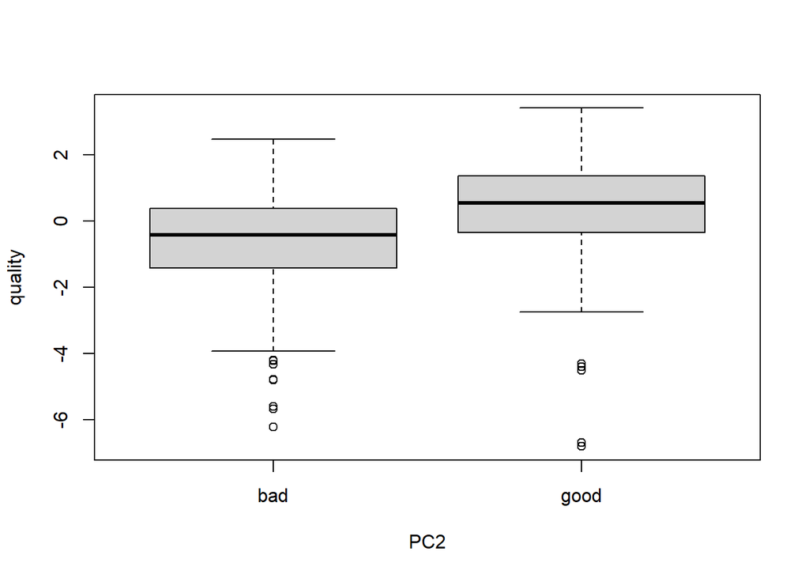

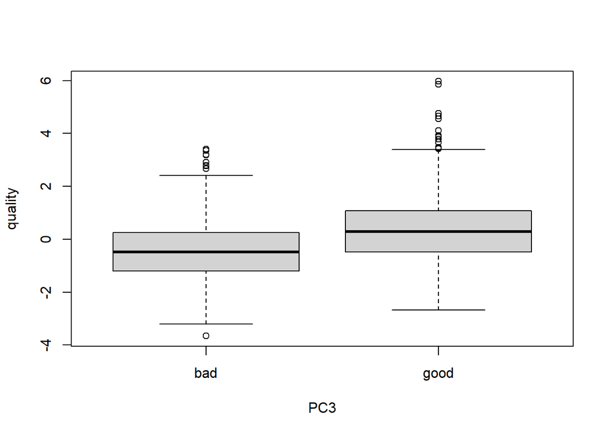

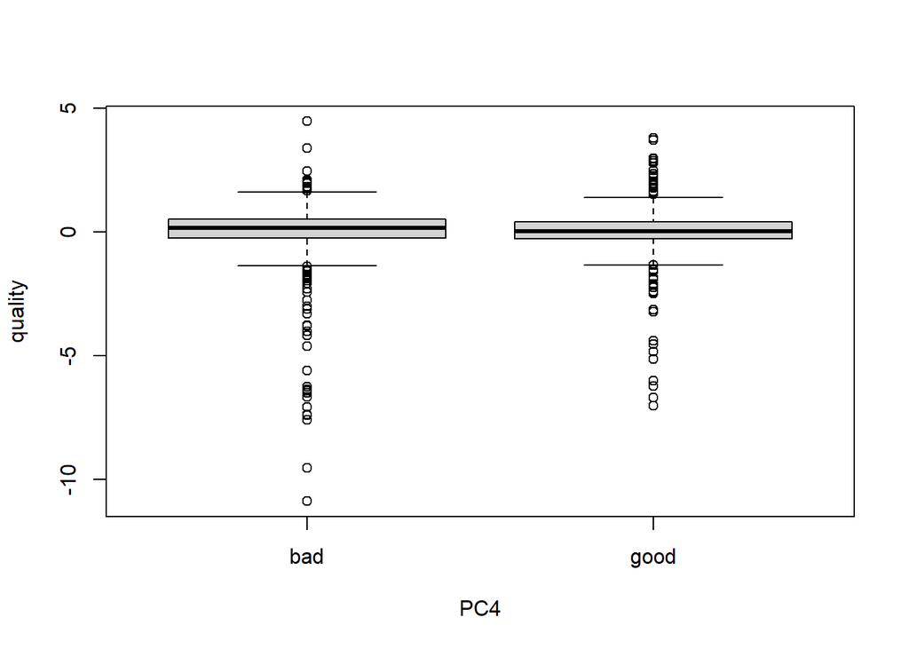

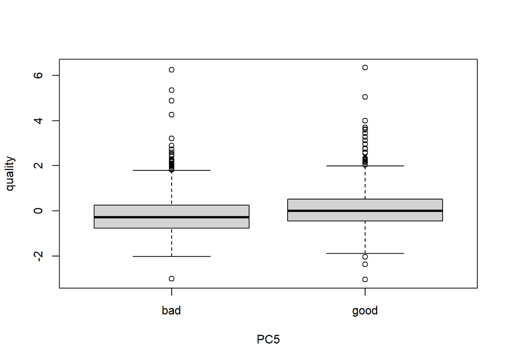

```r
#The aboved two gives us the same thing. predict is a good function to know.
df$quality <- as.factor(df$quality)
out <- sapply(1:5, function(i){plot(df$quality,df_pca$x[,i],xlab=paste("PC",i,sep=""),ylab="quality")})
```

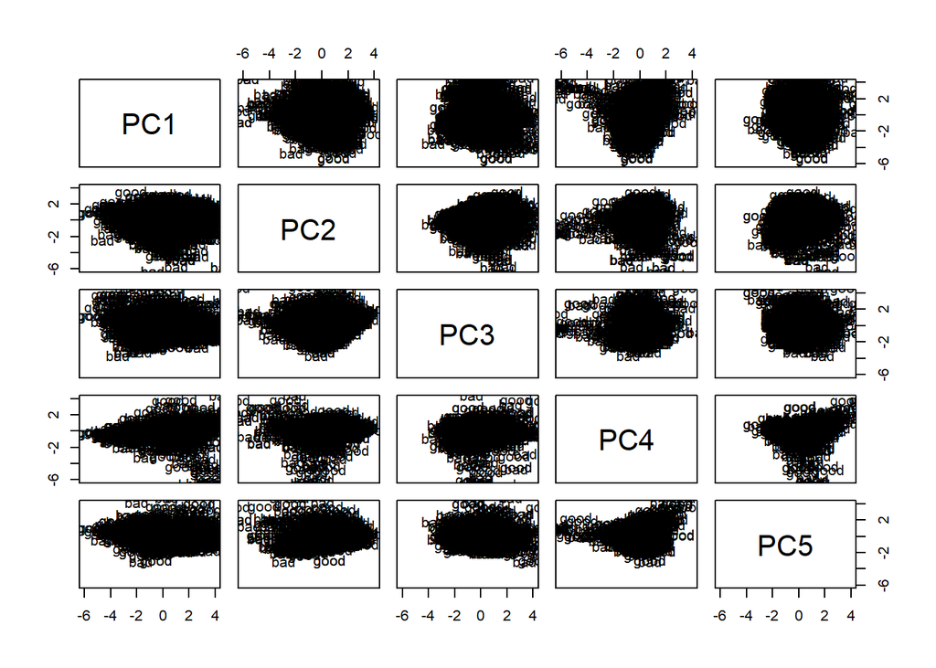

```r
pairs(df_pca$x[,1:5], ylim = c(-6,4),xlim = c(-6,4),panel=function(x,y,...){text(x,y,df$quality)})
```

****Explain the variate representation each PCs**** Multivariate plot:

This used to see contribution of each variable in PC1 to understand variability in data

PC1: [1] fixed acidity, citric acidity and pH are highest contributors towards PC1

PC2: [2] Free sulfur dioxide and total sulfur dioxide are the biggest contributors.

Hence we can deduce that wine quality is good when PC2 is low which means Free sulfur dioxide content and total sulfur dioxide content also should be low

PC3: [3] Alcohol and volatile acidity are the biggest contributors to PC3

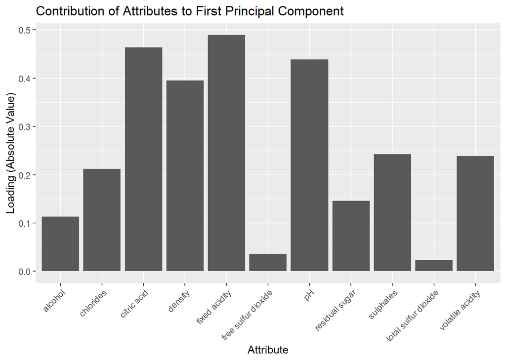

```r
library(ggplot2)
# Extract the loadings from the rotation matrix
loadings <- abs(df_pca$rotation[, 1])  # Assuming you want to visualize the loadings for the first principal component

# Create a data frame for plotting
loadings_df <- data.frame(Attribute = colnames(new_df), Loading = loadings)

# Plot the contributions of each attribute to the first principal component
ggplot(loadings_df, aes(x = Attribute, y = Loading)) +
  geom_bar(stat = "identity") +
  labs(x = "Attribute",
       y = "Loading (Absolute Value)",
       title = "Contribution of Attributes to First Principal Component") +
  theme(axis.text.x = element_text(angle = 45, hjust = 1))  # Rotate x-axis labels for better readability
```

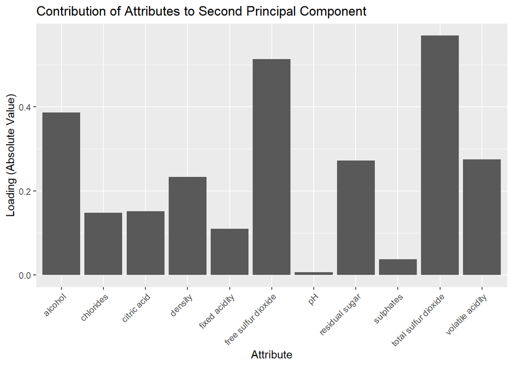

```r
# Extract the loadings from the rotation matrix for PC2
loadings_pc2 <- abs(df_pca$rotation[, 2])
loadings_df_pc2 <- data.frame(Attribute = colnames(new_df), Loading = loadings_pc2)

# Extract the loadings from the rotation matrix for PC3
loadings_pc3 <- abs(df_pca$rotation[, 3])
loadings_df_pc3 <- data.frame(Attribute = colnames(new_df), Loading = loadings_pc3)

# Plot the contributions of each attribute to PC2
ggplot(loadings_df_pc2, aes(x = Attribute, y = Loading)) +
  geom_bar(stat = "identity") +
  labs(x = "Attribute",
       y = "Loading (Absolute Value)",
       title = "Contribution of Attributes to Second Principal Component") +
  theme(axis.text.x = element_text(angle = 45, hjust = 1))  # Rotate x-axis labels for better readability
```

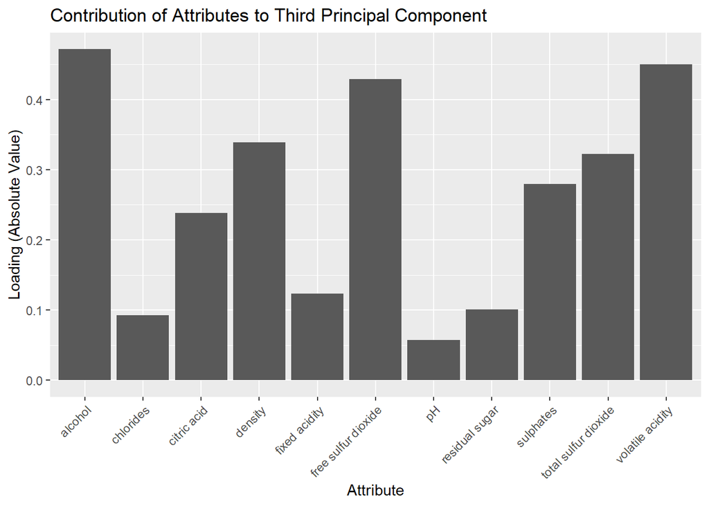

```r
# Plot the contributions of each attribute to PC3
ggplot(loadings_df_pc3, aes(x = Attribute, y = Loading)) +
  geom_bar(stat = "identity") +
  labs(x = "Attribute",
       y = "Loading (Absolute Value)",
       title = "Contribution of Attributes to Third Principal Component") +
  theme(axis.text.x = element_text(angle = 45, hjust = 1))  # Rotate x-axis labels for better readability
```

```r
# Better Ways to Visualize

library(factoextra)
library(FactoMineR)
library(ggfortify)
library(psych)
```

```r
library(corrplot)
library(devtools)
```

Based on correlation plot below we can see that alcohol, citric acid, volatile acid and sulfur dioxide are skewed towards left side which is correlated towards either good or bad value of dependent variable as per extreme skewedness.

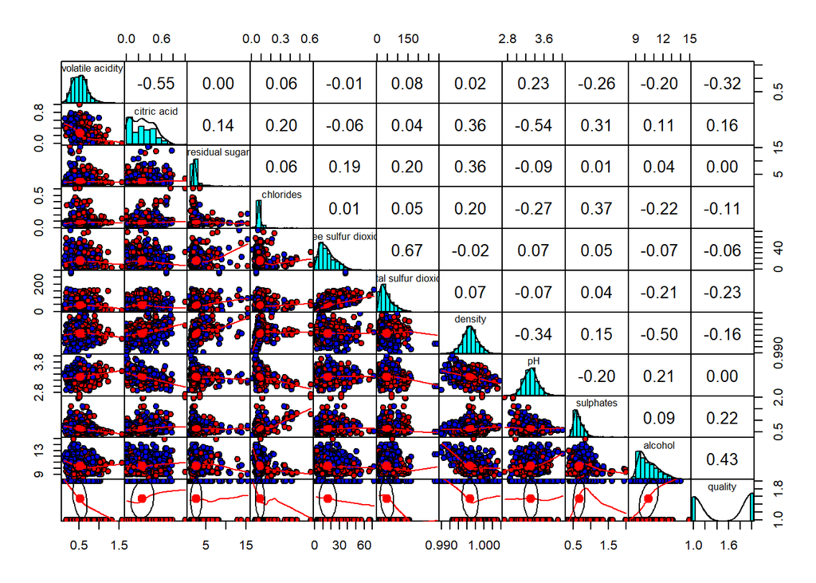

```r
# Correlation
pairs.panels(df[,-1],
             gap = 0,
             bg = c("red", "blue")[df$quality],
             pch=21)
```

PC2, PC3, PC4 and PC5 seem to be highly informative as they are either skewed towards left or right unlike PC1 which uniform and would not help us to predict dependent variable

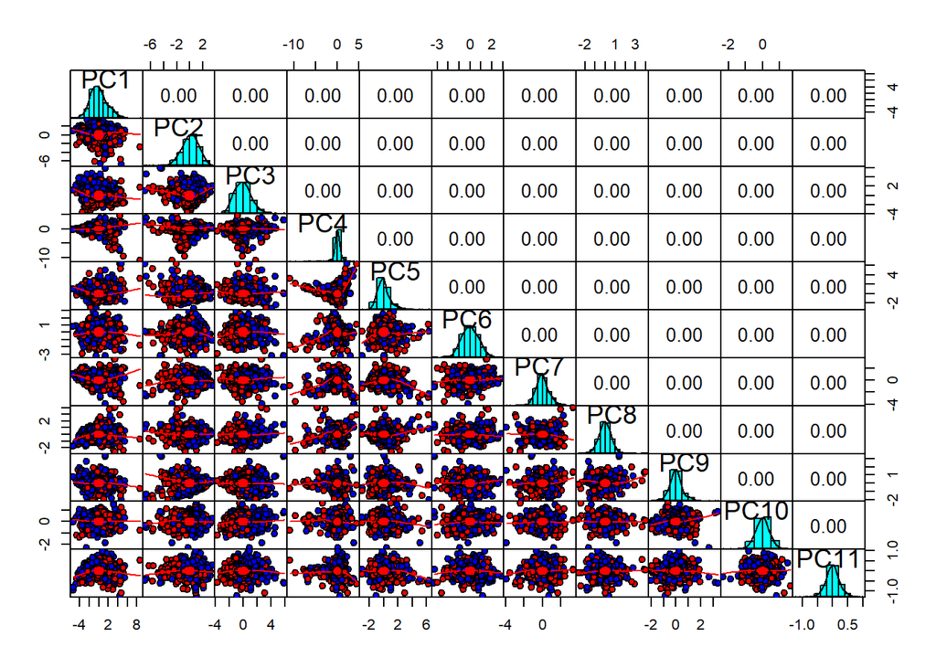

```r
pairs.panels(df_pca$x,
             gap=0,
             bg = c("red", "blue")[df$quality],
             pch=21)
```

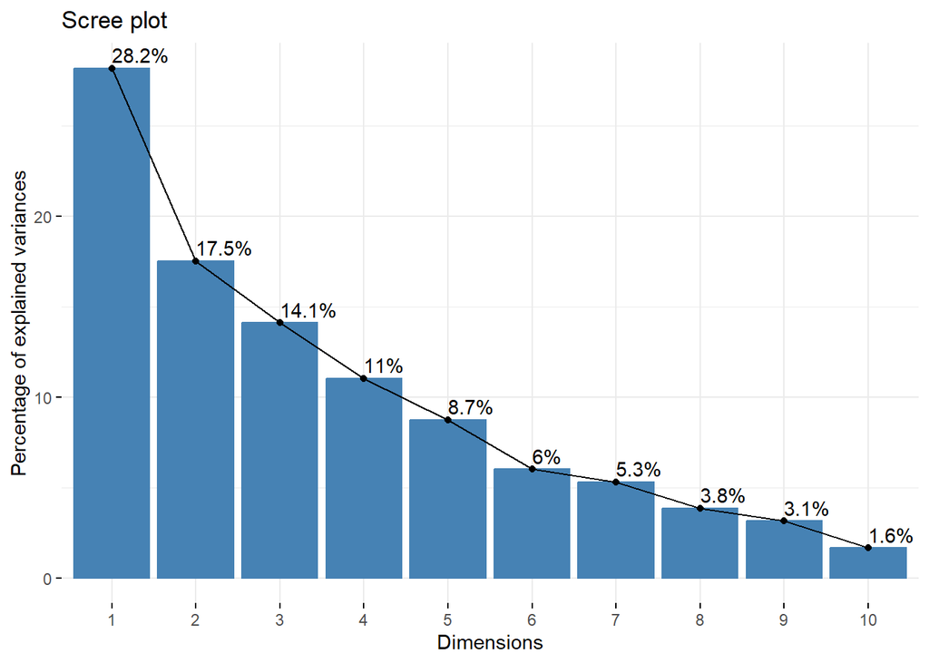

```r
fviz_eig(df_pca, addlabels = TRUE)
```

As we have analyzed that PC2 and PC3 are good indicators of wine quality.

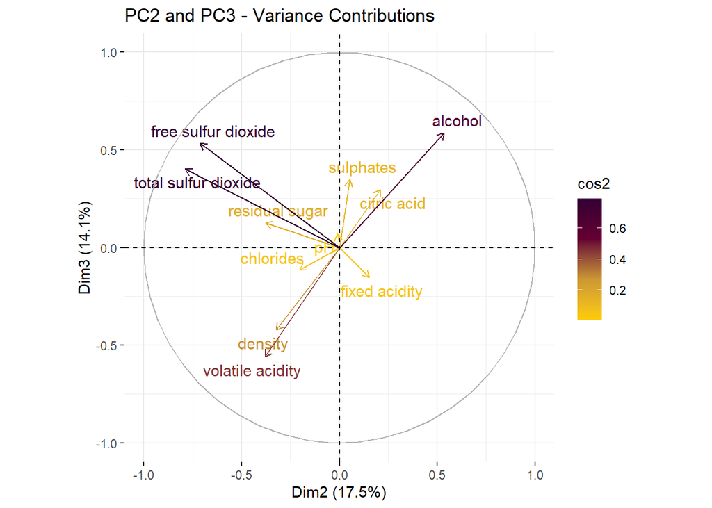

```r
library(factoextra)

# Plot variables' contributions to both PC2 and PC3
plot_pc2_pc3 <- fviz_pca_var(df_pca, axes = c(2, 3), col.var = "cos2",
                              gradient.cols = c("#FFCC00", "#CC9933", "#660033", "#330033"),
                              repel = TRUE) +
  ggtitle("PC2 and PC3 - Variance Contributions")

# Display the plot
plot_pc2_pc3
```

```r
# Different PCA Method.
res.pca <- PCA(df[, 1:11], graph = FALSE)
print(res.pca)
```

```
## **Results for the Principal Component Analysis (PCA)**
## The analysis was performed on 1599 individuals, described by 11 variables
## *The results are available in the following objects:
##
##    name               description
## 1  "$eig"             "eigenvalues"
## 2  "$var"             "results for the variables"
## 3  "$var$coord"       "coord. for the variables"
## 4  "$var$cor"         "correlations variables - dimensions"
## 5  "$var$cos2"        "cos2 for the variables"
## 6  "$var$contrib"     "contributions of the variables"
## 7  "$ind"             "results for the individuals"
## 8  "$ind$coord"       "coord. for the individuals"
## 9  "$ind$cos2"        "cos2 for the individuals"
## 10 "$ind$contrib"     "contributions of the individuals"
## 11 "$call"            "summary statistics"
## 12 "$call$centre"     "mean of the variables"
## 13 "$call$ecart.type" "standard error of the variables"
## 14 "$call$row.w"      "weights for the individuals"
## 15 "$call$col.w"      "weights for the variables"
```

Dim.1:

Dim.1:

PC1: has high cosine similarity with fixed acidity, citric acid, density and pH but still it is evenly distributed hence not meaningful

PC2: has high cosine similarity with total and free sulfuric acid but as per previous analysis high PC2 means bad quality wine hence these attributes contribute towards bad quality wine

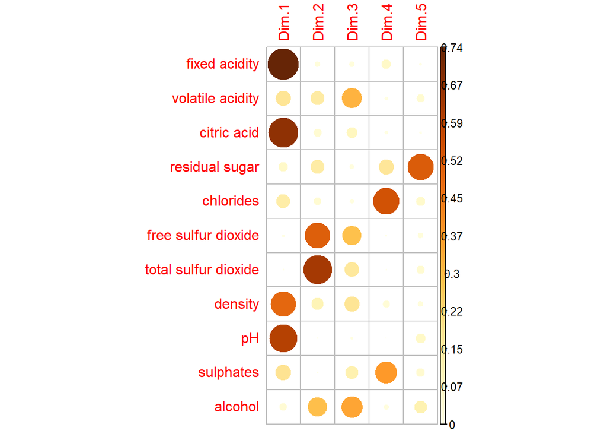

```r
library(corrplot)

# Compute the cos2 values from the PCA results
cos2_matrix <- res.pca$var$cos2

# Plot the correlation matrix using corrplot
corrplot(cos2_matrix, is.corr = FALSE)
```

Below plot confirms on our hypothesis that alcohol and sulfur components contribute towards PC3 and PC2

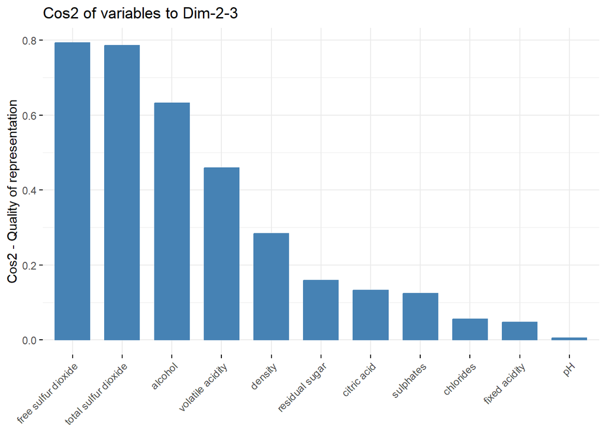

```r
# Total cos2 of variables on Dim.3 and Dim.2
#A high cos2 indicates a good representation of the variable on the principal component.
#In this case the variable is positioned close to the circumference of the correlation circle.
#A low cos2 indicates that the variable is not perfectly represented by the PCs.
#In this case the variable is close to the center of the circle.

fviz_cos2(res.pca, choice = "var", axes = 2:3)
```

Below plot also confirms

as alcohol is positive with PC3 but negative with PC2 indicating good quality wine has high alcohol content

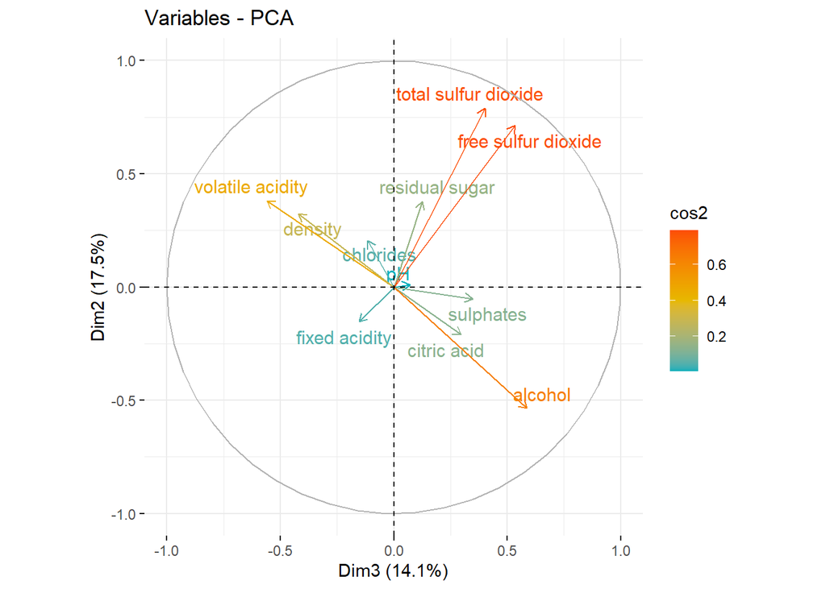

```r
fviz_pca_var(res.pca, col.var = "cos2",
             gradient.cols = c("#00AFBB", "#E7B800", "#FC4E07"),
             repel = TRUE,
             axes = c(3, 2) # Specify PC3 and PC4
             )
```

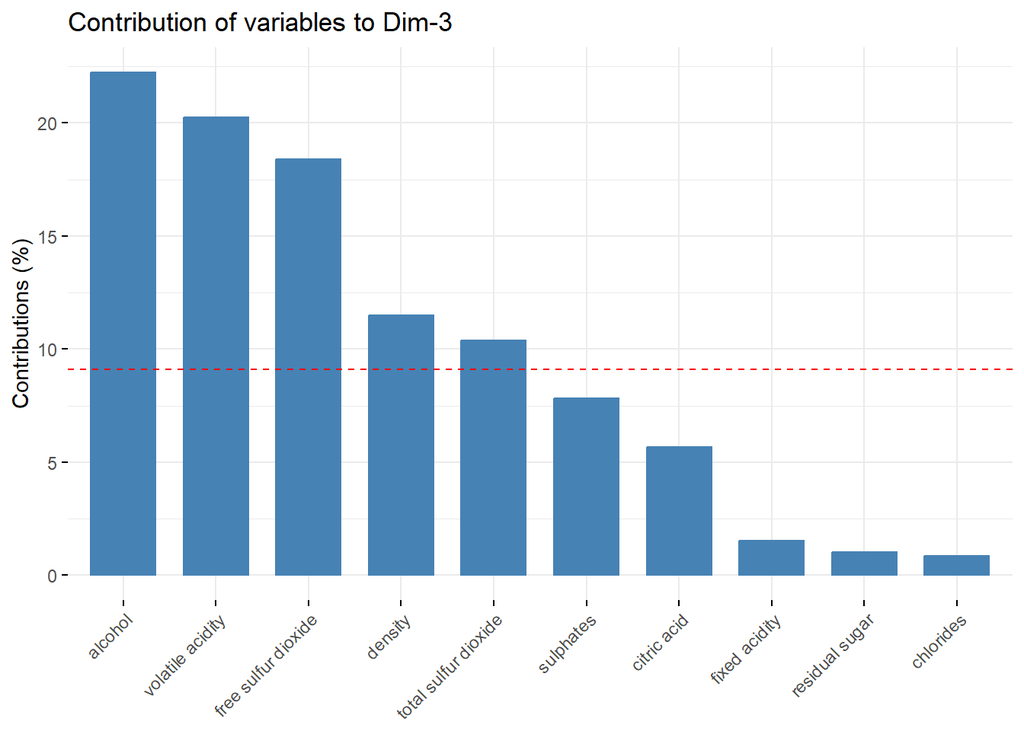

```r
# Contributions of variables to PC1
fviz_contrib(res.pca, choice = "var", axes = 3, top = 10)
```

As per descriptive analysis I can infer these values

For PC1:

```r
# Description of PC

res.desc <- dimdesc(res.pca, axes = c(1,2,3,4,5), proba = 0.05)
# Description of dimension 1
res.desc$Dim.1
```

```
##
## Link between the variable and the continuous variables (R-square)
## =================================================================================
##                     correlation
## fixed acidity        0.86140602
## citric acid          0.81619353
## density              0.69599339
## sulphates            0.42764729
## chlorides            0.37364637
## residual sugar       0.25721219
## free sulfur dioxide -0.06365298
## alcohol             -0.19933772
## volatile acidity    -0.42001233
## pH                  -0.77198543
##                                                                                                                                                                                                                                                                                                          …
## fixed acidity       0.000000000000000000000000000000000000000000000000000000000000…
## citric acid         0.000000000000000000000000000000000000000000000000000000000000…
## density             0.000000000000000000000000000000000000000000000000000000000000…
## sulphates           0.000000000000000000000000000000000000000000000000000000000000…
## chlorides           0.000000000000000000000000000000000000000000000000000003799187…
## residual sugar      0.000000000000000000000000141073721686742487423787961731136419…
## free sulfur dioxide 0.010899171718704622757734057358902646228671073913574218750000…
## alcohol             0.000000000000000857827309288768400860614171676843398017808794…
## volatile acidity    0.000000000000000000000000000000000000000000000000000000000000…
## pH                  0.000000000000000000000000000000000000000000000000000000000000…
```

```r
res.desc$Dim.2
```

```
##
## Link between the variable and the continuous variables (R-square)
## =================================================================================
##                      correlation
## total sulfur dioxide  0.79031776
## free sulfur dioxide   0.71271338
## volatile acidity      0.38154068
## residual sugar        0.37758520
## density               0.32414940
## chlorides             0.20546173
## sulphates            -0.05211625
## fixed acidity        -0.15335255
## citric acid          -0.21065171
## alcohol              -0.53593092
##                                                                                                                                                                                                                                                                               p.value
## total sulfur dioxide 0.000000000000000000000000000000000000000000000000000000000000…
## free sulfur dioxide  0.000000000000000000000000000000000000000000000000000000000000…
## volatile acidity     0.000000000000000000000000000000000000000000000000000000014435…
## residual sugar       0.000000000000000000000000000000000000000000000000000000240155…
## density              0.000000000000000000000000000000000000000194832734169584112608…
## chlorides            0.000000000000000105737035610199820356760319617350774024089332…
## sulphates            0.037179727663202363774352932068723021075129508972167968750000…
## fixed acidity        0.000000000709828893692866404793034851294919462816324084997177…
## citric acid          0.000000000000000017016547883047531263423640668364100747567135…
## alcohol              0.000000000000000000000000000000000000000000000000000000000000…
```

```r
res.desc$Dim.3
```

```
##
## Link between the variable and the continuous variables (R-square)
## =================================================================================
##                      correlation
## alcohol               0.58733137
## free sulfur dioxide   0.53393641
## total sulfur dioxide  0.40147319
## sulphates             0.34839201
## citric acid           0.29666720
## residual sugar        0.12611890
## pH                    0.07184521
## chlorides            -0.11532350
## fixed acidity        -0.15353613
## density              -0.42196539
## volatile acidity     -0.56029703
##                                                                                                                                                                            p.value
## alcohol              0.00000000000000000000000000000000000000000000000000000000000000000000000000000000000000000000000000000000000000000000000000000000000000000000000000006632283
## free sulfur dioxide  0.00000000000000000000000000000000000000000000000000000000000000000000000000000000000000000000000000000000000000000000015584789116505351399058487693594088341
## total sulfur dioxide 0.00000000000000000000000000000000000000000000000000000000000000555112673958350554340168692135648598195984959602355957031250000000000000000000000000000000000
## sulphates            0.00000000000000000000000000000000000000000000007630616372127125938799874216300622720154933631420135498046875000000000000000000000000000000000000000000000000
## citric acid          0.00000000000000000000000000000000075285638670497517159312106382884621780249290168285369873046875000000000000000000000000000000000000000000000000000000000000
## residual sugar       0.00000042046909353701888640078565551050360227236524224281311035156250000000000000000000000000000000000000000000000000000000000000000000000000000000000000000
## pH                   0.00404823459784410446399283145524350402411073446273803710937500000000000000000000000000000000000000000000000000000000000000000000000000000000000000000000000
## chlorides            0.00000377637479046437500498217820776858388853725045919418334960937500000000000000000000000000000000000000000000000000000000000000000000000000000000000000000
## fixed acidity        0.00000000067709585102803639101130828148455975679098628461360931396484375000000000000000000000000000000000000000000000000000000000000000000000000000000000000
## density              0.00000000000000000000000000000000000000000000000000000000000000000000047394567209749809172554535496857397447456605732440948486328125000000000000000000000000
## volatile acidity     0.00000000000000000000000000000000000000000000000000000000000000000000000000000000000000000000000000000000000000000000000000000000000077625050230366088623024
```

```r
res.desc$Dim.4
```

```
##
## Link between the variable and the continuous variables (R-square)
## =================================================================================
##                  correlation
## chlorides          0.7337924
## sulphates          0.6067685
## volatile acidity   0.0869717
## citric acid       -0.0874767
## alcohol           -0.1345786
## density           -0.1922060
## fixed acidity     -0.2529163
## residual sugar    -0.4106192
##                                                                                                                                                                                                                                                                                                 p.value
## chlorides        0.000000000000000000000000000000000000000000000000000000000000…
## sulphates        0.000000000000000000000000000000000000000000000000000000000000…
## volatile acidity 0.000498316172625414346986083558022073702886700630187988281250…
## citric acid      0.000461860319424522069910871158171516981383319944143295288085…
## alcohol          0.000000065959427342164387688197568770931411563651636242866516…
## density          0.000000000000009030428060202416035151529172253503929823637008…
## fixed acidity    0.000000000000000000000000932139643765448967522441181543513266…
## residual sugar   0.000000000000000000000000000000000000000000000000000000000000…
```

```r
res.desc$Dim.5
```

```
##
## Link between the variable and the continuous variables (R-square)
## =================================================================================
##                      correlation
## residual sugar        0.71708742
## alcohol               0.34346950
## pH                    0.26202790
## chlorides             0.24143150
## sulphates             0.22131521
## volatile acidity      0.21423615
## density               0.15384636
## citric acid          -0.05736810
## fixed acidity        -0.08091468
## free sulfur dioxide  -0.15587895
## total sulfur dioxide -0.21788948
##                                                                                                                                                                                                                                                                                   p.value
## residual sugar       0.000000000000000000000000000000000000000000000000000000000000…
## alcohol              0.000000000000000000000000000000000000000000001699318834917645…
## pH                   0.000000000000000000000000016282377638092397594601207222453354…
## chlorides            0.000000000000000000000121988332223686033633277409071737906742…
## sulphates            0.000000000000000000342269317522519176235154536591664964362280…
## volatile acidity     0.000000000000000004684064160466513348449885123514491169771645…
## density              0.000000000625094441651685903994783988224526183330453932285308…
## citric acid          0.021784615656606783062887444657462765462696552276611328125000…
## fixed acidity        0.001202206317184519252308505521398274140665307641029357910156…
## free sulfur dioxide  0.000000000368833135850950954125193614885347415111027657985687…
## total sulfur dioxide 0.000000000000000001227967200531068367279352582244200675631873…
```

```r
# Graph of Indiviuals
ind <- get_pca_ind(res.pca)
ind
```

```
## Principal Component Analysis Results for individuals
##  ===================================================
##   Name       Description
## 1 "$coord"   "Coordinates for the individuals"
## 2 "$cos2"    "Cos2 for the individuals"
## 3 "$contrib" "contributions of the individuals"
```

```r
## Principal Component Analysis Results for individuals
##  ===================================================
##   Name       Description
## 1 "$coord"   "Coordinates for the individuals"
## 2 "$cos2"    "Cos2 for the individuals"
## 3 "$contrib" "contributions of the individuals"
#To get access to the different components, use this:

# Coordinates of individuals
head(ind$coord)
```

```
##        Dim.1      Dim.2      Dim.3       Dim.4       Dim.5
## 1 -1.6195299  0.4509501 -1.7744541  0.04374031  0.06701448
## 2 -0.7991699  1.8565531 -0.9116902  0.54806597 -0.01839156
## 3 -0.7484791  0.8820389 -1.1713942  0.41102067 -0.04353101
## 4  2.3576726 -0.2699760  0.2434887 -0.92844998 -1.49914907
## 5 -1.6195299  0.4509501 -1.7744541  0.04374031  0.06701448
## 6 -1.5837073  0.5691949 -1.5382861  0.02374989 -0.11007597
```

As per below plot (area curve)

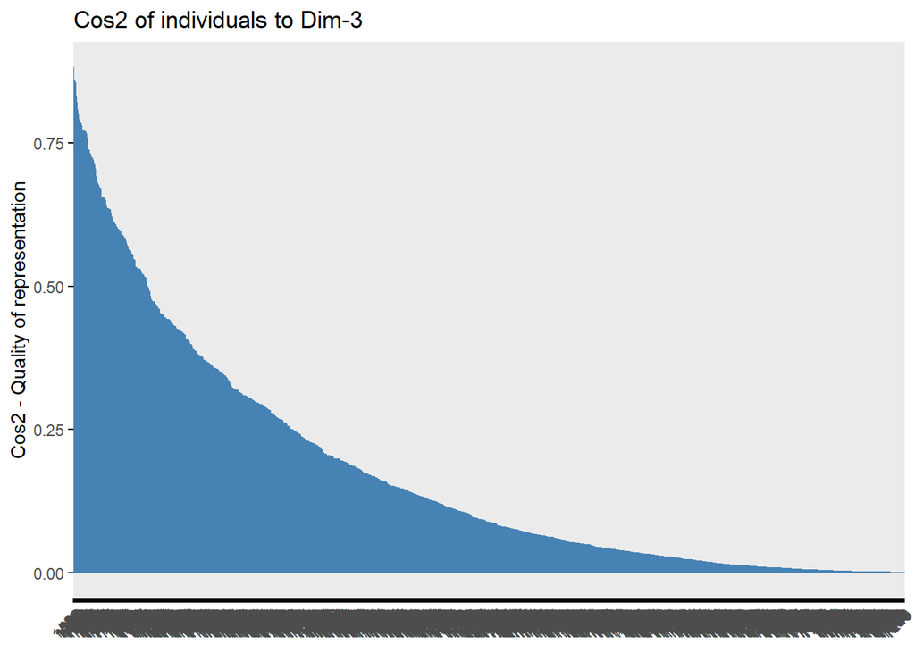

```r
fviz_cos2(res.pca, choice = "ind", axes = 3)
```

Finally we can confirm on our thesis that PC3 is strong indicator of good quality wine as the circle highlighting good quality wine is more towards positive of PC3

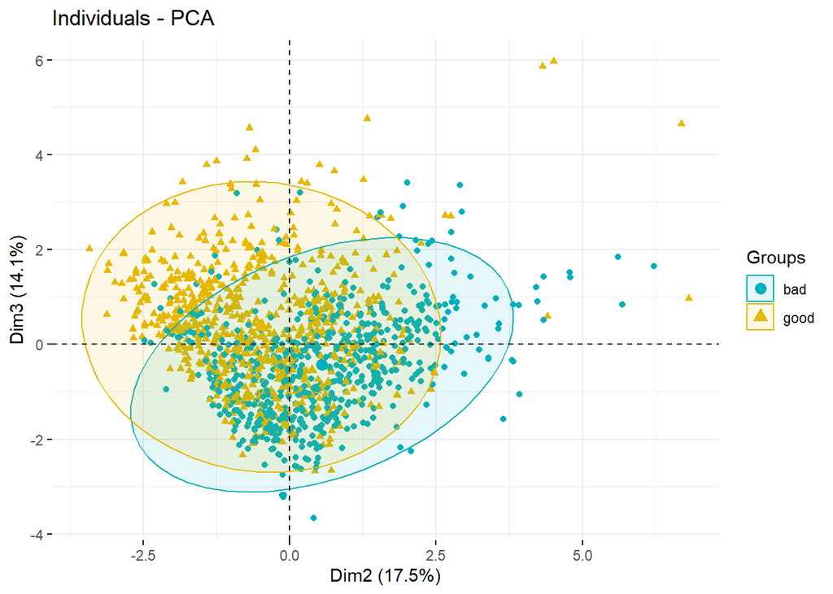

```r
fviz_pca_ind(res.pca,
             geom.ind = "point", # show points only (not "text")
             col.ind = df$quality, # color by groups
             palette = c("#00AFBB", "#E7B800", "#FC4E07"),
             addEllipses = TRUE, # Concentration ellipses
             axes = c(2, 3), # PC2 and PC3
             legend.title = "Groups"
             )
```

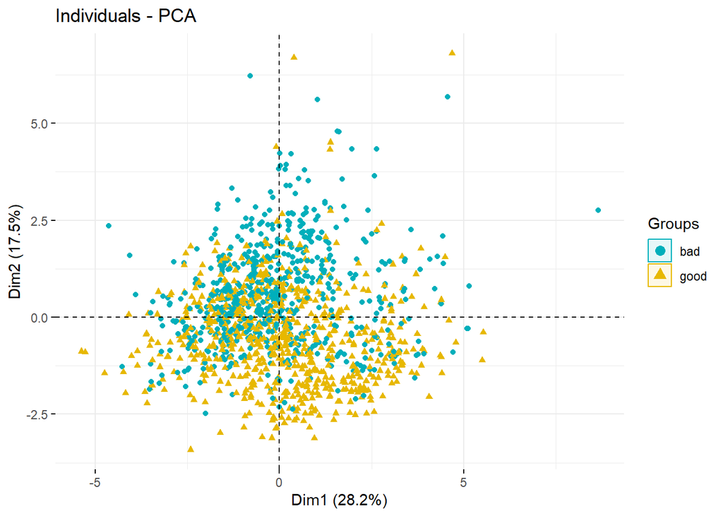

```r
fviz_pca_ind(res.pca, geom.ind = "point", col.ind = df$quality,
             palette = c("#00AFBB", "#E7B800", "#FC4E07"),
             addEllipses = TRUE, ellipse.type = "confidence",
             legend.title = "Groups"
             )
```

PC4 and PC5 are not good indicators of quality of wine as the data points are evenly distribute towards center and also has random outliers.

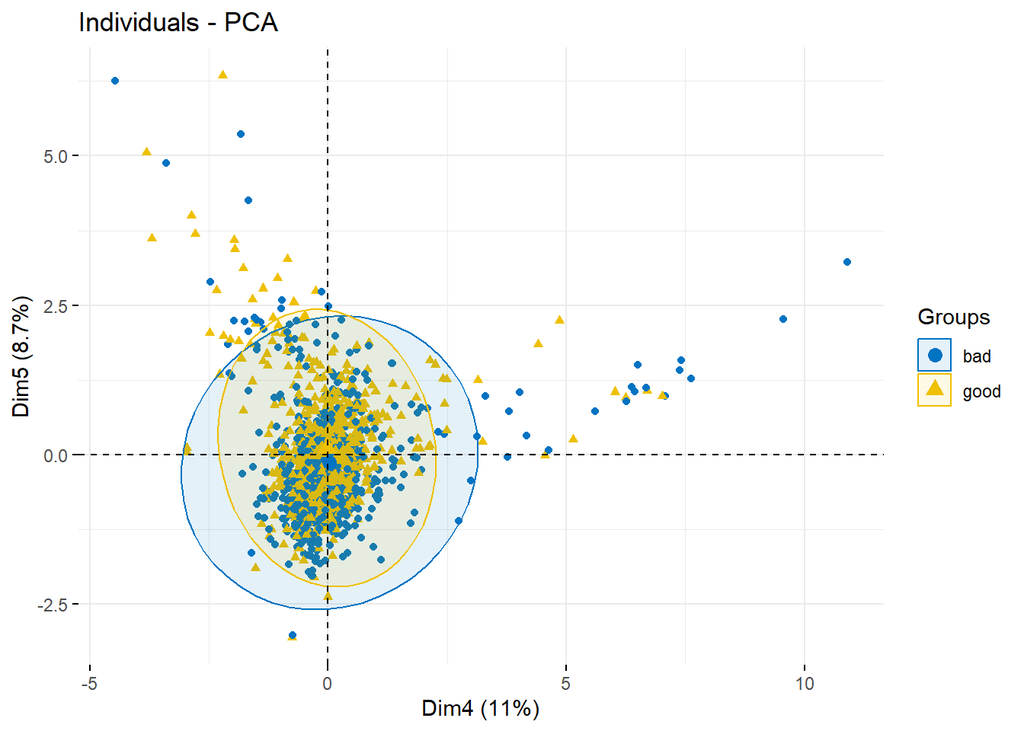

```r
fviz_pca_ind(res.pca,
             label = "none", # hide individual labels
             habillage = df$quality, # color by groups
             addEllipses = TRUE, # Concentration ellipses
             axes = c(4, 5), # PC4 and PC5
             palette = "jco"
             )
```

Alcohol is shows contribution towards good quality wine, along with citric acid which shows little contribution.

Hence we can say that these 2 parameters indicate good rating for wine

Whereas density and volatile acidity show negative correlation and indicate bad quality wine

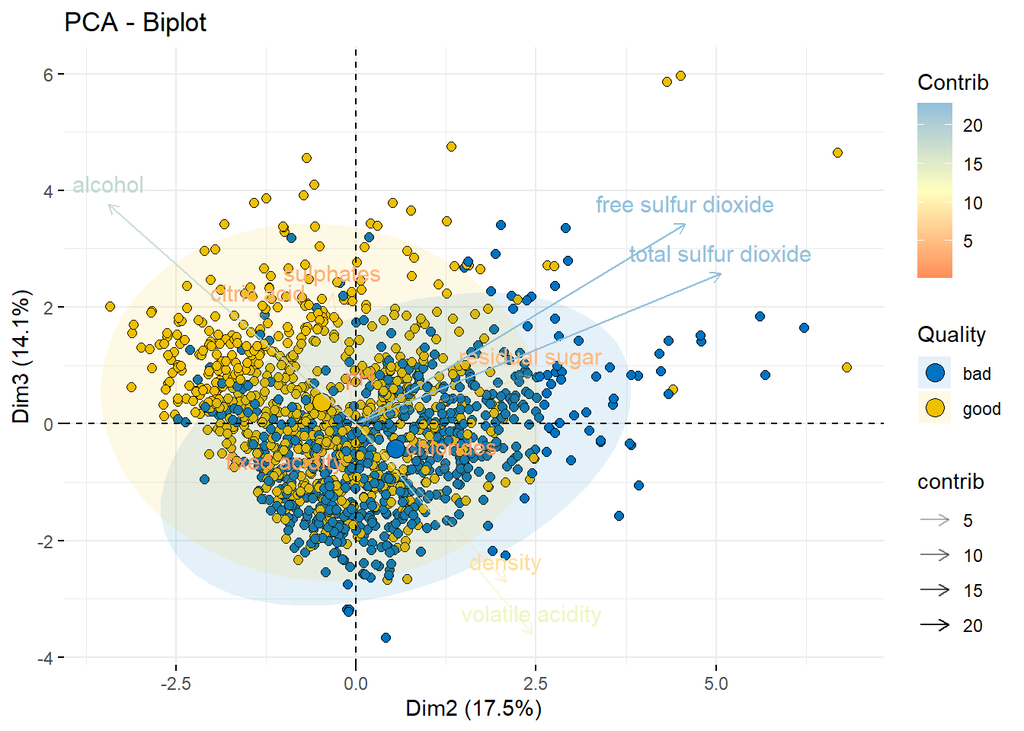

```r
fviz_pca_biplot(res.pca,
                # Individuals
                geom.ind = "point",
                fill.ind = df$quality, col.ind = "black",
                pointshape = 21, pointsize = 2,
                palette = "jco",
                addEllipses = TRUE,
                # Variables
                alpha.var = "contrib", col.var = "contrib",
                gradient.cols = "RdYlBu",
                axes = c(2, 3),  # PC2 and PC3
                legend.title = list(fill = "Quality", color = "Contrib")
                )
```